# Reporte oficial sobre el nivel de pobreza del Perú a nivel provincial

Frank Napán Rodriguez

2022-07-13

**Introducción**

El trabajo realizado en esta sección se centra en el IDH —como variable dependiente— y otras variables que podrían estar relacionadas; es decir, que las variables como el porcentaje de hogares de una provincia que no tiene alumbrado eléctrico por red pública (NoAlumbradoelectxred) y el porcentaje de hogares de una provinca que no tiene acceso a internet en su hogar ( NoConexióninter), podrían tener relación en el Indice de Desarrollo Humano. El indice de Desarrollo humano es un parámetro para cuantificar el avance promedio de un país en tres dimensiones: Esperanza de vida, Salud, acceso al conocimiento y el nivel de vida digno. Sobre estas dos últimas dimensiones, nuestras variables el no NoConexióninter y NoAlumbradoelectxred guardan afinidad.

**Objetivos:**

Son el de verificar si existe relación entre las variables independientes —NoAlumbradoelectxred y NoConexióninter— y la variable dependiente —IDH—; es decir, si las variables independientes podrían explicar el comportamiento de la variable dependiente.

**Glosa de variables:**

- IDH: Indice desarrollo Humano expresado en porcentaje por provincia en el territorio peruano.
- NoAlumbradoelectxred : Hogares que no tienen alumbrado eléctrico por red pública expresado en porcentaje por provincia en el territorio peruano.
- NoConexióninter : Hogares que no tienen conexión a internet expresado en provincia por region en el territorio peruano
- Porcentaje pobreza: Es el porcentaje de pobreza con el que cuenta una provincia en el territorio peruano.

## Traemos la base de datos

```
## 'data.frame':    196 obs. of  6 variables:
##  $ Código              : num  101 102 103 104 105 106 107 201 202 203 ...
##  $ Provincia           : chr  "Chachapoyas" "Bagua" "Bongara" "Condorcanqui" ...
##  $ IDH                 : num  54.3 46.1 41.3 25.4 34.1 ...
##  $ NOAlumbradoelectxred: num  12.5 32.4 17.6 81.6 14.7 ...
##  $ NOConexióninter     : num  89.1 95.3 97 99.4 98 ...
##  $ Porcentaje pobreza  : num  22 34.8 33.2 56.8 48.1 33.2 29.9 14.5 31.7 41.1 ...
```

Veamos una hipotesis: El “IDH” en los distritos del Perú han sido afectados por ‘el porcentaje de hogares que no cuentan con Alumbrado electrico por red’, controlando por ‘porcentaje de pobreza’, la cual se representa en R así:

```r
modelo1= lm(Data$IDH ~ Data$NOAlumbradoelectxred+ Data$`Porcentaje pobreza`, data= Data)

summary(modelo1)
```

```
##
## Call:
## lm(formula = Data$IDH ~ Data$NOAlumbradoelectxred + Data$`Porcentaje pobreza`,
##     data = Data)
##
## Residuals:
##      Min       1Q   Median       3Q      Max
## -13.1420  -3.8389  -0.1288   4.1713  21.1030
##
## Coefficients:
##                           Estimate Std. Error t value Pr(>|t|)
## (Intercept)               68.10647    0.99350  68.552  < 2e-16 ***
## Data$NOAlumbradoelectxred -0.19725    0.03674  -5.369 2.26e-07 ***
## Data$`Porcentaje pobreza` -0.60351    0.03095 -19.499  < 2e-16 ***
## ---
## Signif. codes:  0 '***' 0.001 '**' 0.01 '*' 0.05 '.' 0.1 ' ' 1
##
## Residual standard error: 5.453 on 193 degrees of freedom
## Multiple R-squared:  0.7807, Adjusted R-squared:  0.7784
## F-statistic: 343.5 on 2 and 193 DF,  p-value: < 2.2e-16
```

Veamos el resultado:

```r
library(stargazer)
reg1=lm(modelo1,data=Data)
stargazer(reg1,type = "text",intercept.bottom = FALSE)
```

```
##
## ================================================
##                          Dependent variable:
##                      ---------------------------
##                                  IDH
## ------------------------------------------------
## Constant                      68.106***
##                                (0.993)
##
## NOAlumbradoelectxred          -0.197***
##                                (0.037)
##
## `Porcentaje pobreza`          -0.604***
##                                (0.031)
##
## ------------------------------------------------
## Observations                     196
## R2                              0.781
## Adjusted R2                     0.778
## Residual Std. Error       5.453 (df = 193)
## F Statistic           343.508*** (df = 2; 193)
## ================================================
## Note:                *p<0.1; **p<0.05; ***p<0.01
```

```r
modelo2= lm(Data$IDH ~ Data$NOAlumbradoelectxred+Data$NOConexióninter+ Data$`Porcentaje pobreza`, data= Data)

summary(modelo2)
```

```
##
## Call:
## lm(formula = Data$IDH ~ Data$NOAlumbradoelectxred + Data$NOConexióninter +
##     Data$`Porcentaje pobreza`, data = Data)
##
## Residuals:
##     Min      1Q  Median      3Q     Max
## -11.220  -3.572   0.195   3.459  12.576
##
## Coefficients:
##                           Estimate Std. Error t value Pr(>|t|)
## (Intercept)               99.52074    3.86625  25.741  < 2e-16 ***
## Data$NOAlumbradoelectxred -0.06517    0.03533  -1.845   0.0666 .
## Data$NOConexióninter      -0.43142    0.05179  -8.331  1.5e-14 ***
## Data$`Porcentaje pobreza` -0.45129    0.03227 -13.986  < 2e-16 ***
## ---
## Signif. codes:  0 '***' 0.001 '**' 0.01 '*' 0.05 '.' 0.1 ' ' 1
##
## Residual standard error: 4.685 on 192 degrees of freedom
## Multiple R-squared:  0.8389, Adjusted R-squared:  0.8364
## F-statistic: 333.3 on 3 and 192 DF,  p-value: < 2.2e-16
```

```r
reg2=lm(modelo2,data=Data)
stargazer(reg2,type = "text",intercept.bottom = FALSE)
```

```
##
## ================================================
##                          Dependent variable:
##                      ---------------------------
##                                  IDH
## ------------------------------------------------
## Constant                      99.521***
##                                (3.866)
##
## NOAlumbradoelectxred           -0.065*
##                                (0.035)
##
## NOConexióninter               -0.431***
##                                (0.052)
##
## `Porcentaje pobreza`          -0.451***
##                                (0.032)
##
## ------------------------------------------------
## Observations                     196
## R2                              0.839
## Adjusted R2                     0.836
## Residual Std. Error       4.685 (df = 192)
## F Statistic           333.304*** (df = 3; 192)
## ================================================
## Note:                *p<0.1; **p<0.05; ***p<0.01
```

Ecuación del Modelo 2: IDH=99.521+ -0.065xNoAlumbradoelectxred+ -0.431xNOConexióninter + -0.451xPorcentaje pobreza + ϵ

```r
stargazer(modelo1,modelo2, type ="text")
```

```
##
## ======================================================================
##                                     Dependent variable:
##                      -------------------------------------------------
##                                             IDH
##                                (1)                      (2)
## ----------------------------------------------------------------------
## NOAlumbradoelectxred        -0.197***                 -0.065*
##                              (0.037)                  (0.035)
##
## NOConexióninter                                      -0.431***
##                                                       (0.052)
##
## `Porcentaje pobreza`        -0.604***                -0.451***
##                              (0.031)                  (0.032)
##
## Constant                    68.106***                99.521***
##                              (0.993)                  (3.866)
##
## ----------------------------------------------------------------------
## Observations                   196                      196
## R2                            0.781                    0.839
## Adjusted R2                   0.778                    0.836
## Residual Std. Error      5.453 (df = 193)         4.685 (df = 192)
## F Statistic          343.508*** (df = 2; 193) 333.304*** (df = 3; 192)
## ======================================================================
## Note:                                      *p<0.1; **p<0.05; ***p<0.01
```

El modelo 2 es el que mayor Adjusted R2 tiene (0.836)

```r
tanova=anova(reg1,reg2)
stargazer(tanova,type = 'text',summary = F,title = "Table de Análisis de Varianza")
```

```
##
## Table de Análisis de Varianza
## ==============================================
##   Res.Df    RSS    Df Sum of Sq   F    Pr(> F)
## ----------------------------------------------
## 1  193   5,737.898
## 2  192   4,214.468 1  1,523.430 69.403    0
## ----------------------------------------------
```

Diagnósticos de la Regresión Para que se considere que el modelo de regresión elegido es el adecuado, debemos verificar algunos requisitos a posteriori:

1. Linealidad:

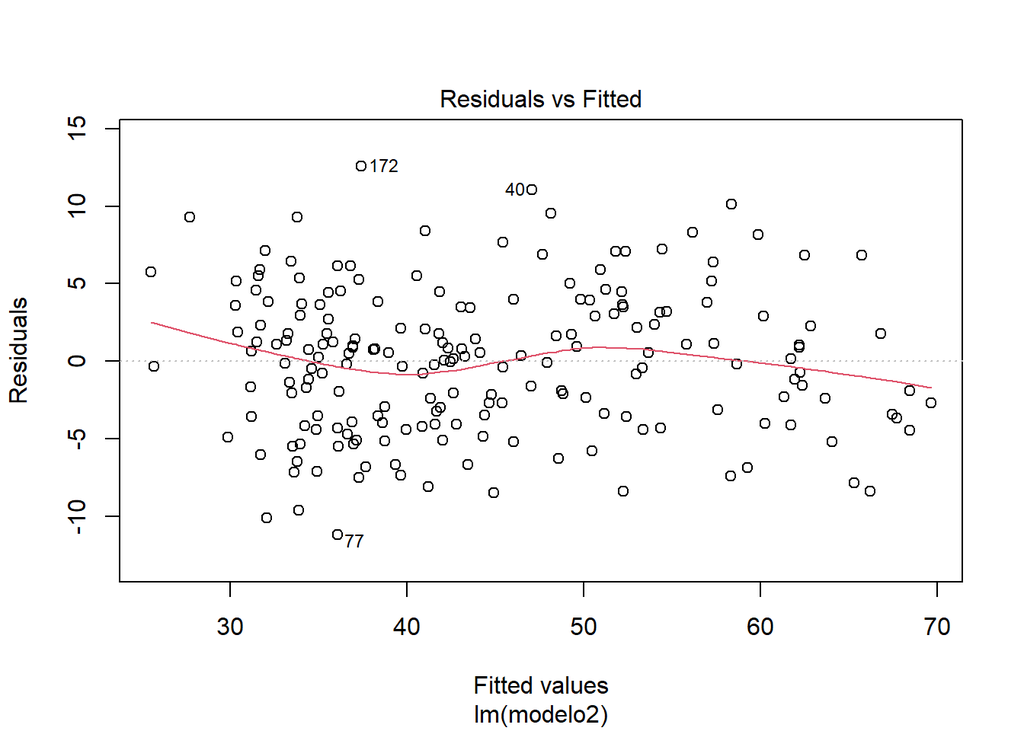

```r
plot(reg2,1)
```

2.Homocedasticidad ( La línea roja debe tener tendencia a la horizontalidad)

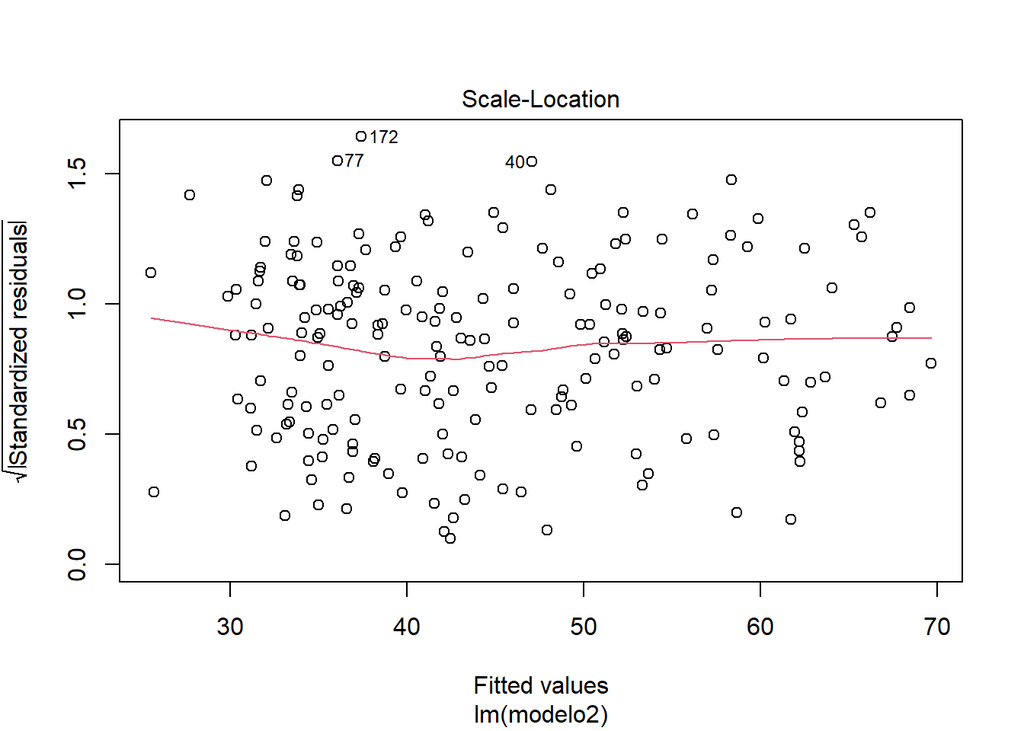

```r
plot(reg2,3)
```

Otra forma de observar la homocedasticidad

```r
library(lmtest)
bptest(reg2)
```

```
##
##  studentized Breusch-Pagan test
##
## data:  reg2
## BP = 3.3781, df = 3, p-value = 0.3369
```

La probabilidad de homocedasticidad es alta pues el (p-value mayor a 0.05.

3. Normal idad de los residuos (distribución de los residuos)

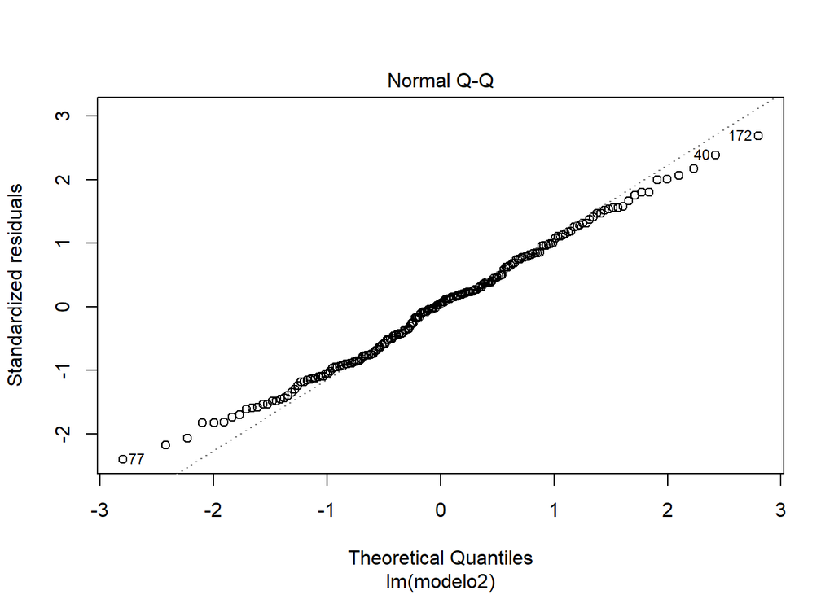

```r
plot(reg2, 2)
```

Es lineal, es una distribución mayormente normal

```r
shapiro.test(reg2$residuals)
```

```
##
##  Shapiro-Wilk normality test
##
## data:  reg2$residuals
## W = 0.99405, p-value = 0.6234
```

El P-value es mayor a 0.05, por ende, hay normalidad

4. No Multicolinelidad ( variables independientes no son muy similares)

```r
library(DescTools)
VIF(reg2) # > 5 es problematico(retirarlo del estudio)
```

```
## Data$NOAlumbradoelectxred      Data$NOConexióninter Data$`Porcentaje pobreza`
##                  1.673452                  2.430632                  1.967242
```

Ninguno es mayor a 5; por ende, niguna es candidata a ser retirada

5. Valores influyentes:

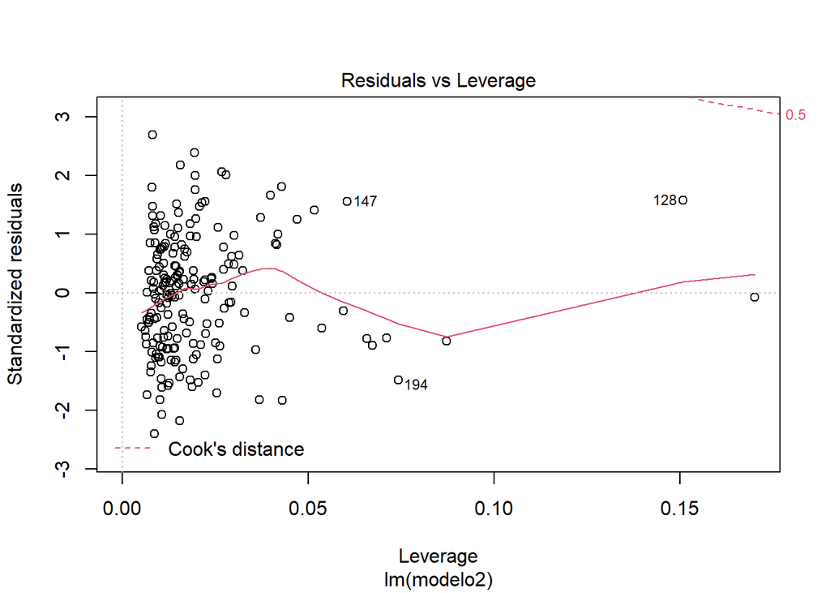

```r
plot(reg2, 5)
```

No hay variables influyentes

```r
checkReg2=as.data.frame(influence.measures(reg2)$is.inf)
head(checkReg2)
```

|  | dfb.1_ | dfb.D$NOA | dfb.D$NOC | dfb.D$`p | dffit | cov.r | cook.d | hat |
| --- | --- | --- | --- | --- | --- | --- | --- | --- |
| 1 | FALSE | FALSE | FALSE | FALSE | FALSE | FALSE | FALSE | FALSE |
| 2 | FALSE | FALSE | FALSE | FALSE | FALSE | FALSE | FALSE | FALSE |
| 3 | FALSE | FALSE | FALSE | FALSE | FALSE | FALSE | FALSE | FALSE |
| 4 | FALSE | FALSE | FALSE | FALSE | FALSE | TRUE | FALSE | TRUE |
| 5 | FALSE | FALSE | FALSE | FALSE | FALSE | FALSE | FALSE | FALSE |
| 6 | FALSE | FALSE | FALSE | FALSE | FALSE | FALSE | FALSE | FALSE |

```r
checkReg2[checkReg2$cook.d & checkReg2$hat,]
```

| dfb.1_ | dfb.D$NOA | dfb.D$NOC | dfb.D$`p | dffit | cov.r | cook.d | hat |
| --- | --- | --- | --- | --- | --- | --- | --- |

No hay valores que afecten la regresión.

**Conclusiones:**

**PARTE 2. CLUSTERIZACIONES**

**Introducción**: En esta sección observamos a las provincias de todo el Perú, que cuentan con variables que los podrían hacer parecidos entre sí o diferenciarse unos a otros, es decir, que si los clasificamos podrían, por ejemplo, dividirse entre provincias con mejor Indice de desarrollo humano, regular indice de desarrollo humano o el más bajo nivel de desarrollo. Estos indicadores nos ayudarían a visualizar en que parte del Perú hay mayor rezago en el servicio de red electrica, acceso a internet, y acceso a la educación.

Obejtivos:

Los objetivos de esta parte son el de clasificar a las provincias en grupos de acuerdo a sus varibles, asimismo, identificar en donde hay mayor rezago con respecto a sus variables.

**Glosa de variables:**

- IDH: Indice desarrollo Humano expresado en porcentaje por provincia en el territorio peruano.
- NoAlumbradoelectxred : Hogares que no tienen alumbrado eléctrico por red pública expresado en porcentaje por provincia en el territorio peruano.
- NoConexióninter : Hogares que no tienen conexión a internet expresado en provincia por region en el territorio peruano
- Porcentaje pobreza: Es el porcentaje de pobreza con el que cuenta una provincia en el territorio peruano.
- InstiteducEnotrodist : Porcentaje de personas en una provincia estudiaron en instituciones educativos fuera del distrito donde residían.

## Datos del GitHub

```r
library("rio")
lkXLSX="https://github.com/FrankNapan/TRABAJO-FINAL/blob/main/Base.FNR.xlsx?raw=true"
Data1=import(lkXLSX)


lkXLSX2="https://github.com/camilachurampi03/Trabajo-Grupal/blob/main/basedata_CM.xlsx?raw=true"
Data2=import(lkXLSX2)
```

```r
str(Data1)
```

```
## 'data.frame':    196 obs. of  6 variables:
##  $ Código              : num  101 102 103 104 105 106 107 201 202 203 ...
##  $ Provincia           : chr  "Chachapoyas" "Bagua" "Bongara" "Condorcanqui" ...
##  $ IDH                 : num  54.3 46.1 41.3 25.4 34.1 ...
##  $ NOAlumbradoelectxred: num  12.5 32.4 17.6 81.6 14.7 ...
##  $ NOConexióninter     : num  89.1 95.3 97 99.4 98 ...
##  $ Porcentaje pobreza  : num  22 34.8 33.2 56.8 48.1 33.2 29.9 14.5 31.7 41.1 ...
```

```r
str(Data2)
```

```
## 'data.frame':    196 obs. of  6 variables:
##  $ codigo          : num  101 102 103 104 105 106 107 201 202 203 ...
##  $ provincias      : chr  "Chachapoyas" "Bagua" "Bongara" "Condorcanqui" ...
##  $ porpobre        : num  22 34.8 33.2 56.8 48.1 33.2 29.9 14.5 31.7 41.1 ...
##  $ poblacion       : num  0.555 0.741 0.256 0.425 0.444 ...
##  $ SinNivel        : num  6.3 9.77 9.37 12.79 12.56 ...
##  $ InstotroDistrito: num  7.89 6.72 13.56 2.69 8.36 ...
```

## Uniendo Data1 y Data2

```r
list(names(Data1), names(Data2))
```

```
## [[1]]
## [1] "Código"               "Provincia"            "IDH"
## [4] "NOAlumbradoelectxred" "NOConexióninter"      "Porcentaje pobreza"
##
## [[2]]
## [1] "codigo"           "provincias"       "porpobre"         "poblacion"
## [5] "SinNivel"         "InstotroDistrito"
```

```r
keep=c(2,3,4,5)
data=Data1[,keep]
keep2=c(2,6)
data2=Data2[,keep2]
colnames(data2)=c("Provincia","InstiteducEnotrodist")
```

```r
merge(data,data2)
```

| Provincia | IDH | NOAlumbradoelectxred | NOConexióninter | InstiteducEnotrodist |
| --- | --- | --- | --- | --- |
| Abancay | 52.13 | 9.34 | 81.07 | 12.357614 |
| Acobamba | 30.87 | 20.10 | 97.32 | 9.349112 |
| Acomayo | 29.77 | 22.32 | 99.09 | 17.140808 |
| Aija | 36.93 | 21.28 | 96.86 | 9.887761 |
| Alto Amazonas | 43.58 | 28.41 | 91.85 | 2.516011 |
| Ambo | 37.54 | 27.78 | 94.50 | 15.333604 |
| Andahuaylas | 42.19 | 20.91 | 90.78 | 14.450292 |
| Angaraes | 32.59 | 31.80 | 96.60 | 11.337098 |
| Anta | 39.45 | 18.45 | 94.32 | 23.735609 |
| Antabamba | 32.31 | 31.10 | 99.61 | 7.362146 |

[output cut: 186 more lines]

```r
Alldata=merge(data, data2, by="Provincia")
```

```r
str(Alldata)
```

```
## 'data.frame':    196 obs. of  5 variables:
##  $ Provincia           : chr  "Abancay" "Acobamba" "Acomayo" "Aija" ...
##  $ IDH                 : num  52.1 30.9 29.8 36.9 43.6 ...
##  $ NOAlumbradoelectxred: num  9.34 20.1 22.32 21.28 28.41 ...
##  $ NOConexióninter     : num  81.1 97.3 99.1 96.9 91.8 ...
##  $ InstiteducEnotrodist: num  12.36 9.35 17.14 9.89 2.52 ...
```

```r
summary(Alldata)
```

```
##   Provincia              IDH        NOAlumbradoelectxred NOConexióninter
##  Length:196         Min.   :21.96   Min.   : 1.72        Min.   :50.24
##  Class :character   1st Qu.:35.42   1st Qu.:13.45        1st Qu.:85.97
##  Mode  :character   Median :42.27   Median :20.09        Median :95.58
##                     Mean   :44.41   Mean   :22.15        Mean   :90.90
##                     3rd Qu.:54.31   3rd Qu.:29.16        3rd Qu.:98.00
##                     Max.   :72.55   Max.   :81.56        Max.   :99.84
##  InstiteducEnotrodist
##  Min.   : 1.370
##  1st Qu.: 7.322
##  Median :11.421
##  Mean   :13.455
##  3rd Qu.:17.213
##  Max.   :50.903
```

```r
str(Alldata)
```

```
## 'data.frame':    196 obs. of  5 variables:
##  $ Provincia           : chr  "Abancay" "Acobamba" "Acomayo" "Aija" ...
##  $ IDH                 : num  52.1 30.9 29.8 36.9 43.6 ...
##  $ NOAlumbradoelectxred: num  9.34 20.1 22.32 21.28 28.41 ...
##  $ NOConexióninter     : num  81.1 97.3 99.1 96.9 91.8 ...
##  $ InstiteducEnotrodist: num  12.36 9.35 17.14 9.89 2.52 ...
```

```r
library(BBmisc)
```

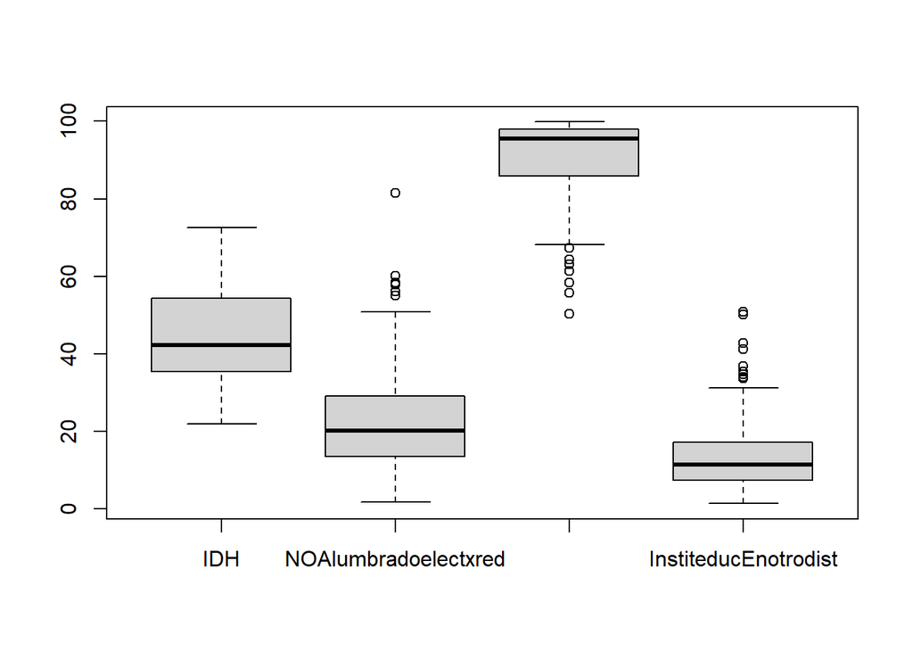

```r
boxplot(Alldata[,-1])
```

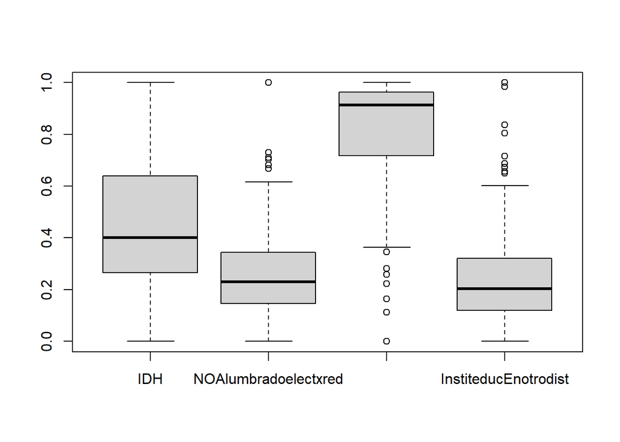

```r
boxplot(normalize(Alldata[,-1],method='range',range=c(0,1)))
```

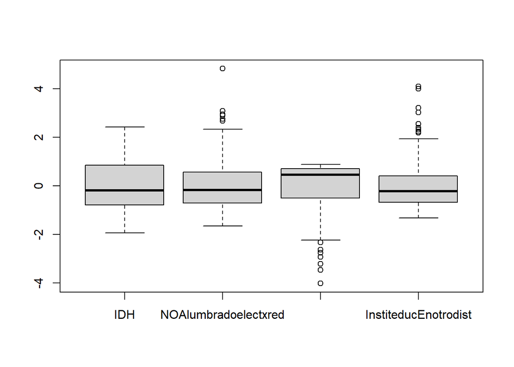

```r
boxplot(normalize(Alldata[,-1], method= 'standardize'))
```

Nos quedaremos con la última opción. POR QUÉ?

```r
Alldata[,-1]=normalize(Alldata[,-1],method='standardize')
Alldata=Alldata[complete.cases(Alldata),]
```

```r
summary(Alldata)
```

```
##   Provincia              IDH          NOAlumbradoelectxred NOConexióninter
##  Length:196         Min.   :-1.9381   Min.   :-1.6628      Min.   :-4.0251
##  Class :character   1st Qu.:-0.7761   1st Qu.:-0.7080      1st Qu.:-0.4878
##  Mode  :character   Median :-0.1847   Median :-0.1671      Median : 0.4637
##                     Mean   : 0.0000   Mean   : 0.0000      Mean   : 0.0000
##                     3rd Qu.: 0.8545   3rd Qu.: 0.5711      3rd Qu.: 0.7028
##                     Max.   : 2.4294   Max.   : 4.8358      Max.   : 0.8854
##  InstiteducEnotrodist
##  Min.   :-1.3212
##  1st Qu.:-0.6705
##  Median :-0.2225
##  Mean   : 0.0000
##  3rd Qu.: 0.4108
##  Max.   : 4.0940
```

Veamos Correlaciones

```r
cor(Alldata[,-1])
```

```
##                             IDH NOAlumbradoelectxred NOConexióninter
## IDH                   1.0000000           -0.5904488      -0.8152477
## NOAlumbradoelectxred -0.5904488            1.0000000       0.6279892
## NOConexióninter      -0.8152477            0.6279892       1.0000000
## InstiteducEnotrodist  0.5809316           -0.4624884      -0.6245525
##                      InstiteducEnotrodist
## IDH                             0.5809316
## NOAlumbradoelectxred           -0.4624884
## NOConexióninter                -0.6245525
## InstiteducEnotrodist            1.0000000
```

practiquemos cambio de monotonia:

```r
Alldata$InstiteducEnotrodist=-1*Alldata$InstiteducEnotrodist
#ahora:
cor(Alldata[,-1])
```

```
##                             IDH NOAlumbradoelectxred NOConexióninter
## IDH                   1.0000000           -0.5904488      -0.8152477
## NOAlumbradoelectxred -0.5904488            1.0000000       0.6279892
## NOConexióninter      -0.8152477            0.6279892       1.0000000
## InstiteducEnotrodist -0.5809316            0.4624884       0.6245525
##                      InstiteducEnotrodist
## IDH                            -0.5809316
## NOAlumbradoelectxred            0.4624884
## NOConexióninter                 0.6245525
## InstiteducEnotrodist            1.0000000
```

Preparemos la data (Alldata) para la clusterización

```r
DataClus=Alldata[,-1]
row.names(DataClus)=Alldata$Provincia
```

##Proceso de Clusterización:

```r
library("cluster")
g.dist = daisy(DataClus, metric="gower")
```

##Calcular el número de Clusters:

Para Partición (pam)

```r
library("factoextra")
```

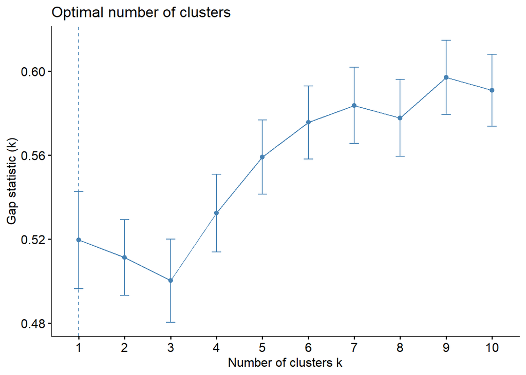

```r
fviz_nbclust(DataClus, pam,diss=g.dist,method= "gap_stat",k.max= 10, verbose = F)
```

Para Jerarquica - Aglomerativa (AGNES)

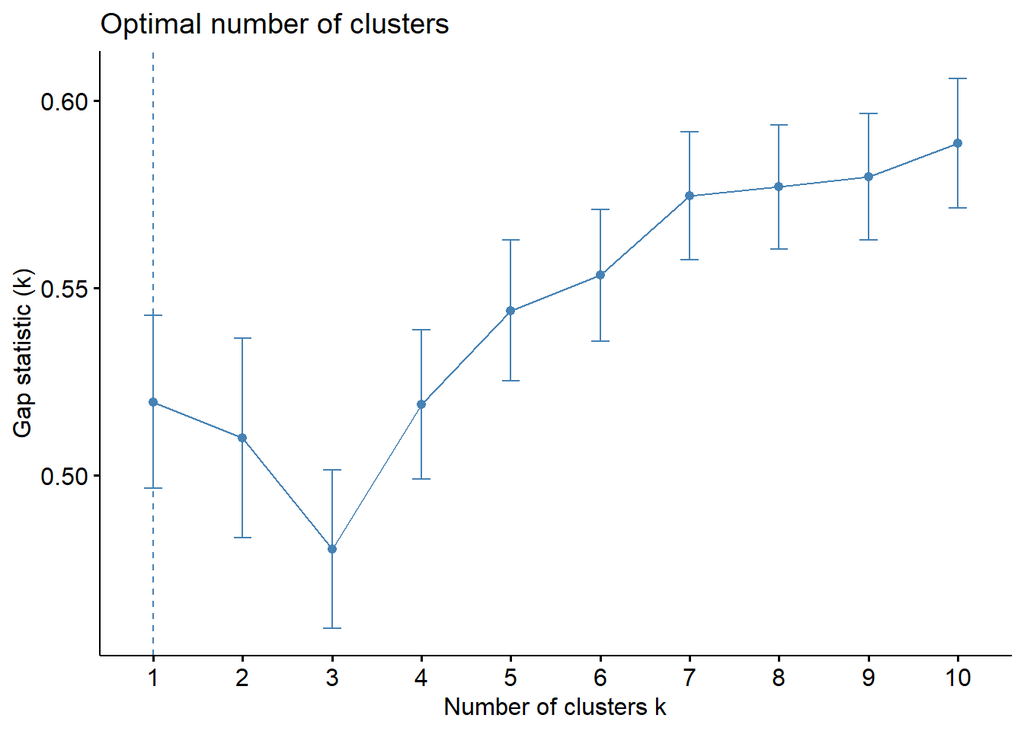

```r
fviz_nbclust(DataClus, hcut,diss=g.dist,method = "gap_stat",k.max = 10,verbose = F,hc_func =
"agnes")
```

Para Jerarquica - Divisiva (DIANA)

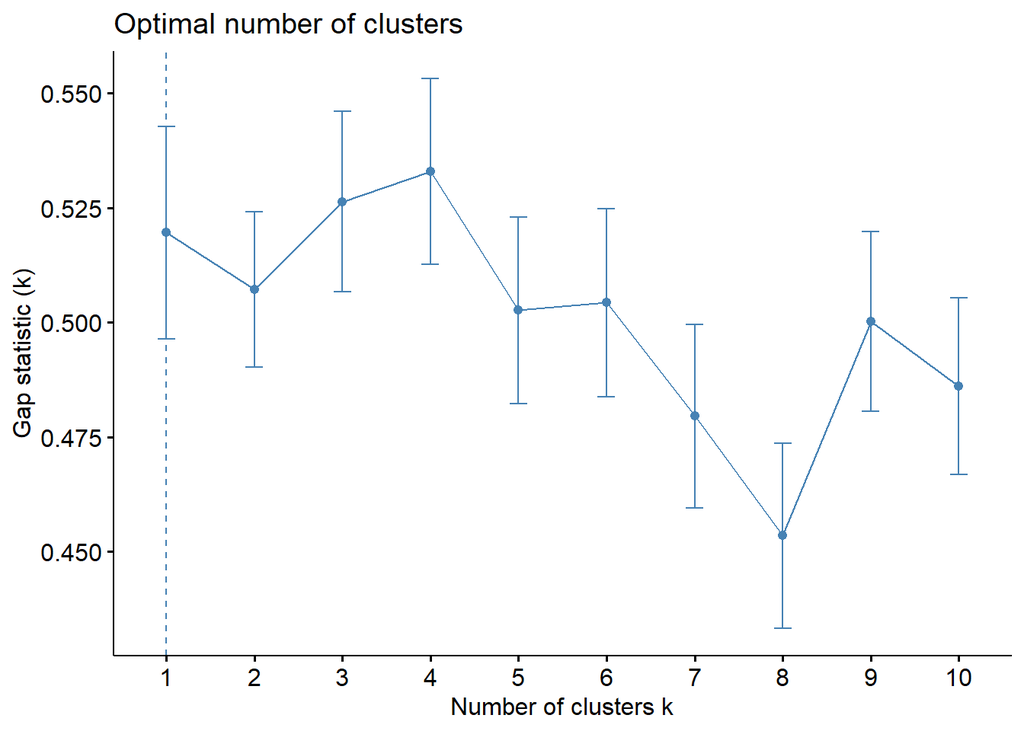

```r
fviz_nbclust(DataClus, hcut,diss=g.dist,method = "gap_stat",k.max = 10,verbose = F,hc_func = "diana")
```

#Evaluemos resultados

```r
###pam
set.seed(123)
grupos=4
res.pam=pam(g.dist,k = grupos,cluster.only = F)
DataClus$pam=res.pam$cluster
```

```r
###agnes
library(factoextra)
library(ggplot2)
res.agnes<- hcut(g.dist, k =grupos,hc_func='agnes',hc_method = "ward.D")
DataClus$agnes=res.agnes$cluster
```

```r
### diana
res.diana <- hcut(g.dist, k = grupos,hc_func='diana')
DataClus$diana=res.diana$cluster
```

Veamos cuál de ellos fue el mejor:

PAM

```
##   cluster size ave.sil.width
## 1       1   40          0.31
## 2       2   70          0.24
## 3       3   54          0.22
## 4       4   32          0.26
```

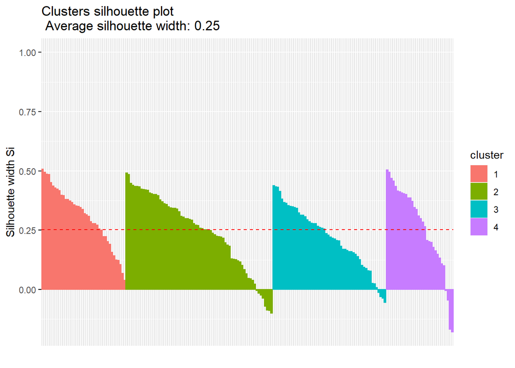

```r
fviz_silhouette(res.pam)
```

AGNES

```
##   cluster size ave.sil.width
## 1       1   56          0.22
## 2       2   80          0.29
## 3       3   48          0.21
## 4       4   12          0.41
```

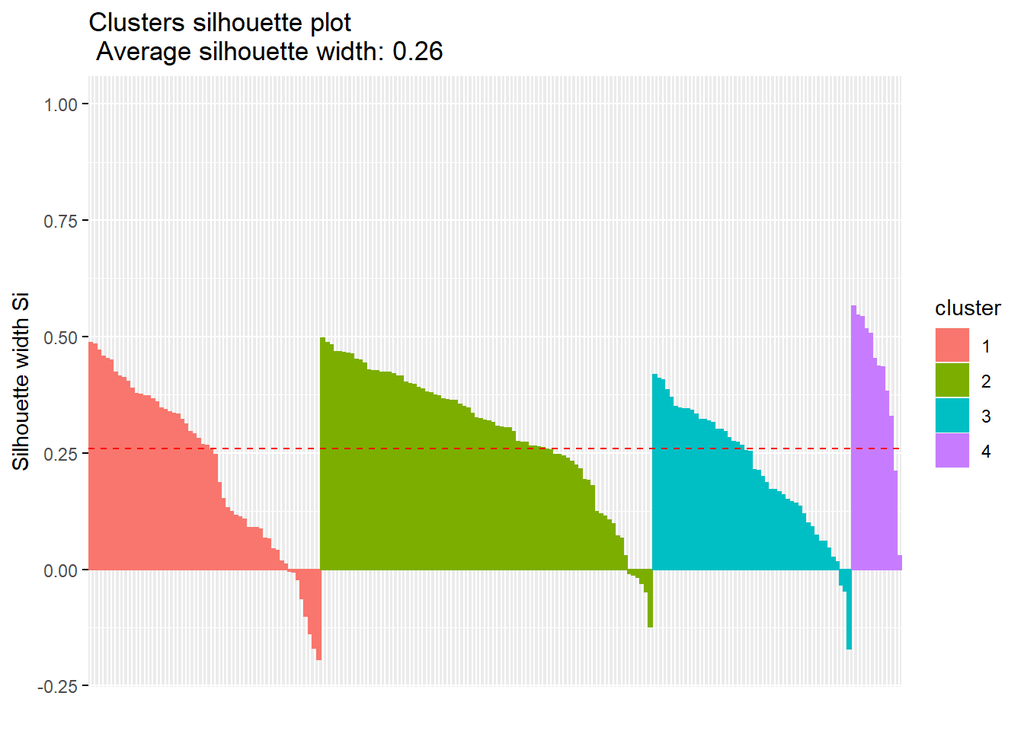

```r
fviz_silhouette(res.agnes)
```

DIANA

```
##   cluster size ave.sil.width
## 1       1   55          0.26
## 2       2   70          0.29
## 3       3   59          0.23
## 4       4   12          0.39
```

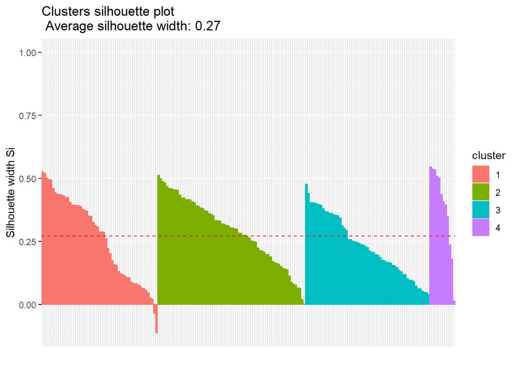

```r
fviz_silhouette(res.diana)
```

Concluímos que los datos fueron mejor clusterizados usando el método jerarquico divisivo (Diana)

##Graficando

```r
original=aggregate(.~ diana, data=DataClus,mean)
original[order(original$NOAlumbradoelectxred),]
```

|  | diana | IDH | NOAlumbradoelectxred | NOConexióninter | InstiteducEnotrodist | pam | agnes |
| --- | --- | --- | --- | --- | --- | --- | --- |
| 4 | 4 | 1.6959070 | -1.26564296 | -2.6442932 | -2.1449191 | 4.000000 | 3.750000 |
| 1 | 1 | 1.0288339 | -0.74145088 | -0.7833950 | -0.4882737 | 2.090909 | 1.090909 |
| 3 | 3 | -0.1742847 | -0.03612517 | 0.4152077 | 0.1129412 | 2.745763 | 2.728814 |
| 2 | 2 | -0.9521993 | 0.82998427 | 0.7188713 | 0.6561507 | 2.071429 | 2.028571 |

Observar si debemos ordenar los resultados de una mejor manera

```r
DataClus$diana=dplyr::recode(DataClus$diana, `4` = 1, `2`=4,`3`=3,`1`=2)
```

Proyectamos los casos en dos dimensiones (k es la cantidad de dimensiones)

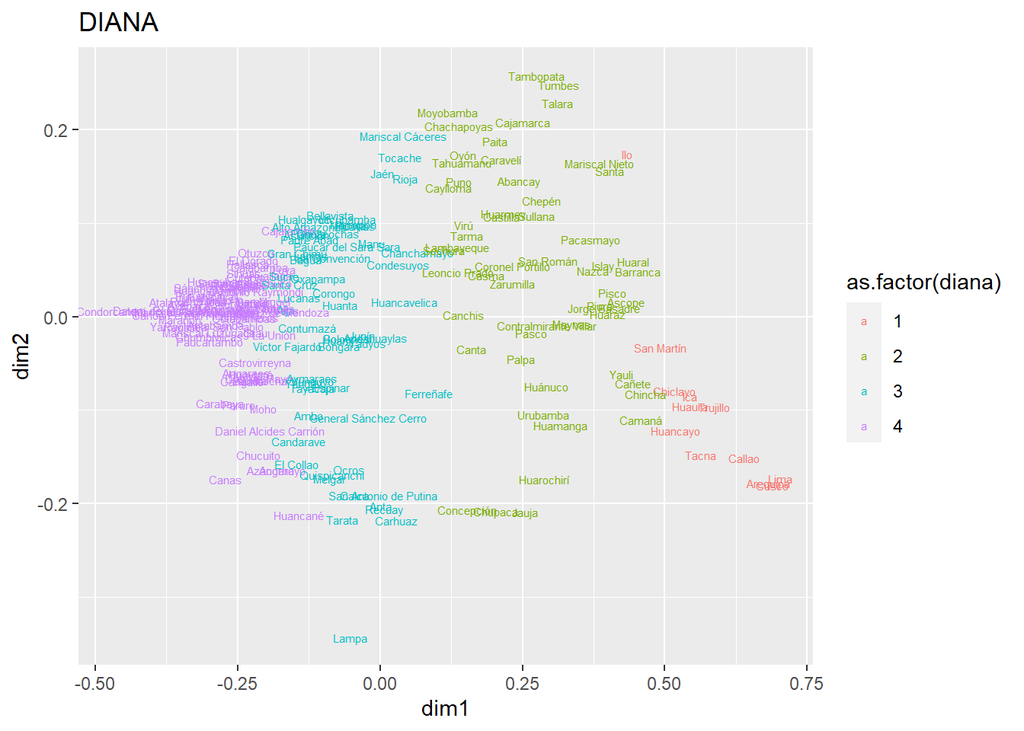

```r
proyeccion = cmdscale(g.dist, k=2,add = T)
DataClus$dim1 <- proyeccion$points[,1]
DataClus$dim2 <- proyeccion$points[,2]
base= ggplot(DataClus,aes(x=dim1, y=dim2,label=row.names(DataClus)))
base + geom_text(size=2, aes(color=as.factor(diana))) + labs(title = "DIANA")
```

###Analisis factorial

Buscaremos saber si el conjunto de vairbles explica el IDH

```r
keep3=c(2,3,4,5)
data3=Data1[,keep3]
keep4=c(2,6)
data4=Data2[,keep4]

colnames(data4) = c("Provincia","InstiteducEnotrodist")
```

```r
merge(data3,data4)
```

| Provincia | IDH | NOAlumbradoelectxred | NOConexióninter | InstiteducEnotrodist |
| --- | --- | --- | --- | --- |
| Abancay | 52.13 | 9.34 | 81.07 | 12.357614 |
| Acobamba | 30.87 | 20.10 | 97.32 | 9.349112 |
| Acomayo | 29.77 | 22.32 | 99.09 | 17.140808 |
| Aija | 36.93 | 21.28 | 96.86 | 9.887761 |
| Alto Amazonas | 43.58 | 28.41 | 91.85 | 2.516011 |
| Ambo | 37.54 | 27.78 | 94.50 | 15.333604 |
| Andahuaylas | 42.19 | 20.91 | 90.78 | 14.450292 |
| Angaraes | 32.59 | 31.80 | 96.60 | 11.337098 |
| Anta | 39.45 | 18.45 | 94.32 | 23.735609 |
| Antabamba | 32.31 | 31.10 | 99.61 | 7.362146 |

[output cut: 186 more lines]

```r
DATAAF=merge(data3, data4, by="Provincia")
```

Calculo de la matriz de correlación

```r
dontselect=c("Provincia","IDH")
select=setdiff(names(DATAAF),dontselect)
theData=DATAAF[,select] # sin el IDH ni Provincia.
```

```r
library(polycor)
corMatrix=polycor::hetcor(theData)$correlations
```

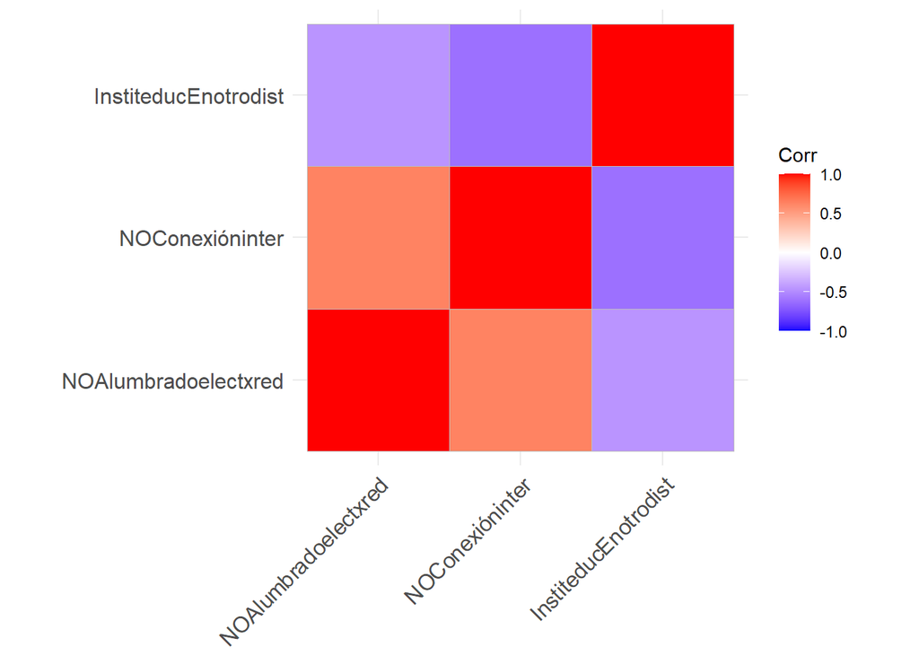

```r
library(ggcorrplot)
ggcorrplot(corMatrix)
```

3. Verificar si los datos permiten factorizar:

```r
library(psych)
psych::KMO(corMatrix)
```

```
## Kaiser-Meyer-Olkin factor adequacy
## Call: psych::KMO(r = corMatrix)
## Overall MSA =  0.67
## MSA for each item =
## NOAlumbradoelectxred      NOConexióninter InstiteducEnotrodist
##                 0.71                 0.62                 0.71
```

4. Verificar si la matriz de correlaciones es adecuada

Hnula: La matriz de correlacion es una matriz identidad

```r
cortest.bartlett(corMatrix,n=nrow(theData))$p.value>0.05
```

```
## [1] FALSE
```

Hnula: La matriz de correlacion es una matriz singular

```r
library(matrixcalc)
is.singular.matrix(corMatrix)
```

```
## [1] FALSE
```

Ahora determinaremos en cuantos factores o variables latentes podríamos redimensionar la data:

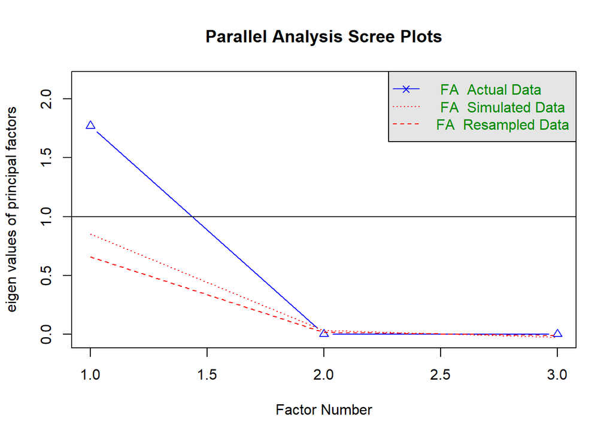

```
## Parallel analysis suggests that the number of factors =  1  and the number of components =  NA
```

```r
fa.parallel(theData,fm = 'ML', fa = 'fa',correct = T)
```

El cuadro nos dice que las tres variables deberían organizarse en 1 factor.

Redimensionar a numero menor de factores, como nos dijo la pruega anterior a uno solo. Lo cual era lo que esperabamos.

```r
library(GPArotation)
resfa <- fa(theData,
 nfactors = 1,
 cor = 'mixed',
 rotate = "varimax",
 fm="minres")
print(resfa$loadings)
```

```
##
## Loadings:
##                      MR1
## NOAlumbradoelectxred  0.682
## NOConexióninter       0.921
## InstiteducEnotrodist -0.678
##
##                  MR1
## SS loadings    1.773
## Proportion Var 0.591
```

Podemos observar que la varible que aporta más al factor es la falta de internet en los hogares ( NoConexióninter), pues tiene un valor de 0.921. La que le sigue es la falta de alumbrado por rede pública (NoAlumbradoelecxred)

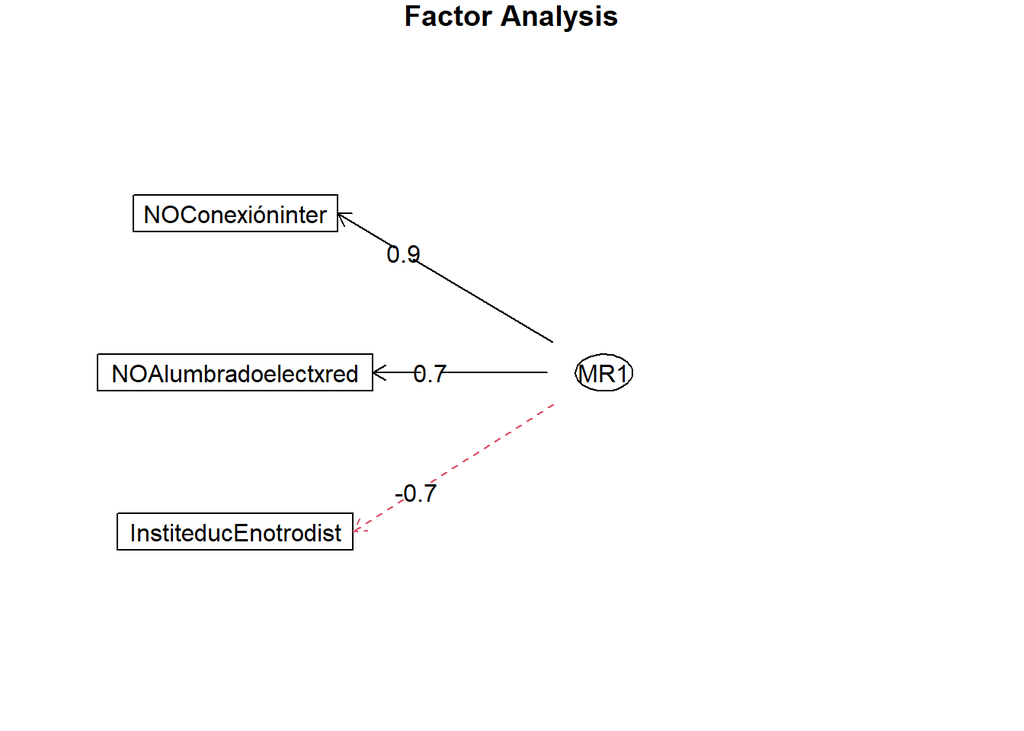

```r
fa.diagram(resfa)
```

¿Qué variables aportaron mas a los factores?

```r
sort(resfa$communality)
```

```
## InstiteducEnotrodist NOAlumbradoelectxred      NOConexióninter
##            0.4599575            0.4650333            0.8480477
```

¿Qué variables contribuyen a mas de un factor?

```r
sort(resfa$complexity)
```

```
## InstiteducEnotrodist      NOConexióninter NOAlumbradoelectxred
##                    1                    1                    1
```

Observamos que los tres obtinen la unidad, por ende, diríamos que todas aportan de manera significativa.

Posibles valores proyectados:

```r
library(BBmisc)
library(dplyr)
library()
```

```r
as.data.frame(resfa$scores)%>%head()
```

|  | MR1 |
| --- | --- |
| 1 | -0.8521130 |
| 2 | 0.5065362 |
| 3 | 0.5333469 |
| 4 | 0.4791304 |
| 5 | 0.3280670 |
| 6 | 0.2997425 |

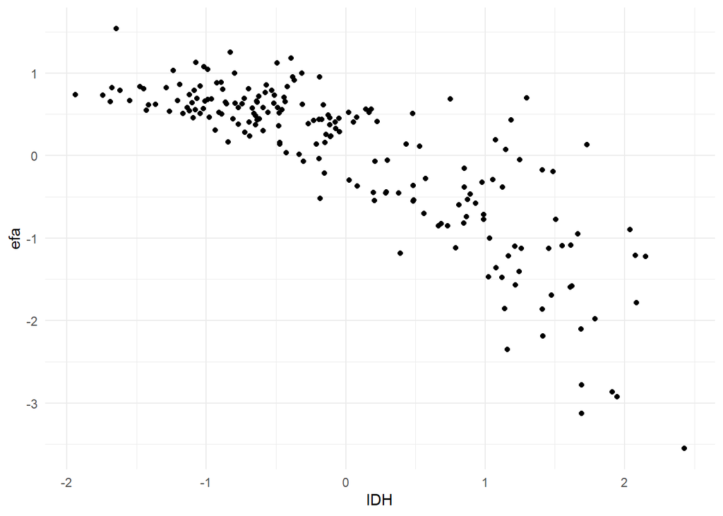

```r
Alldata$efa=resfa$scores
ggplot(data=Alldata,aes(x=IDH ,y=efa)) + geom_point() + theme_minimal()
```

Observamos la correlación del IDH, el cual tiene similitud a la base cargada. La debilidad del gráfico es que va desde valores positivos a negativos. Notamos que los valores no son pareceidos por ello le daremos un rango del 0 al 10.

Este sería el resultado de un rango 0 al 10

```r
Alldata$efa_ok=normalize(Alldata$efa,
 method = "range",
 margin=2, # by column
 range = c(0, 10))
```

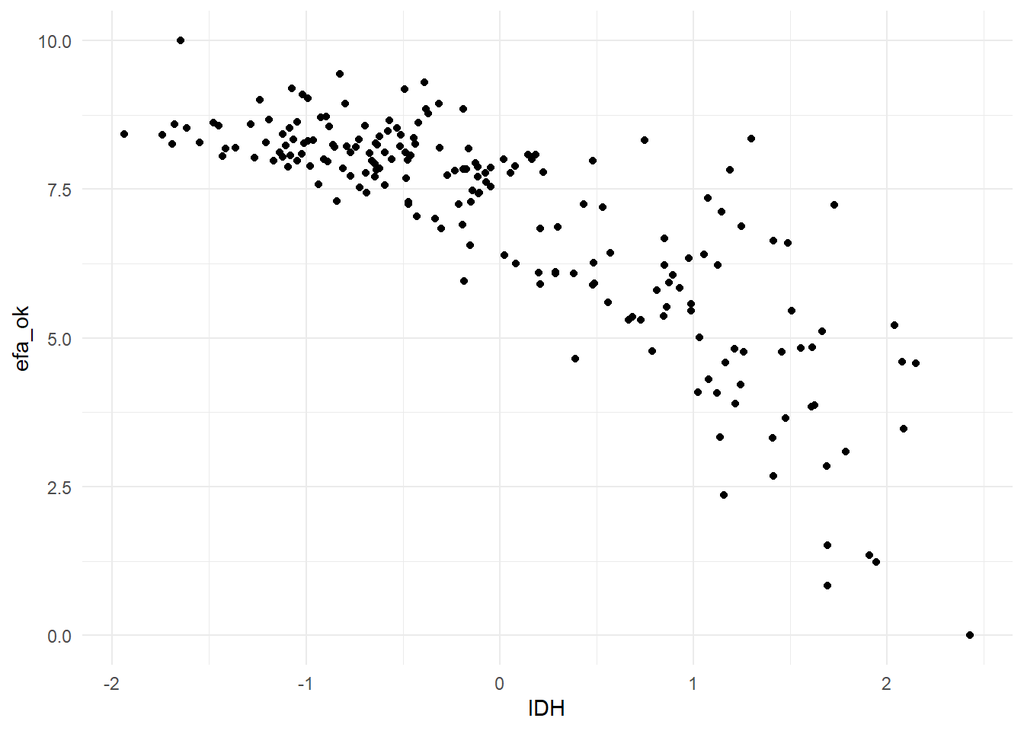

```r
ggplot(data=Alldata,aes(x=IDH,y=efa_ok)) + geom_point() + theme_minimal()
```

Analisis confirmatorio

```r
model <- ' IDH =~ NOAlumbradoelectxred + NOConexióninter + InstiteducEnotrodist'
```

```r
library(lavaan)
theDataNorm=as.data.frame(scale(theData))
```

```r
cfa_fit <- cfa(model, data=theDataNorm,
 std.lv=TRUE,
 missing="fiml")
```

```r
allParamCFA=parameterEstimates(cfa_fit,standardized = T)
allFitCFA=as.list(fitMeasures(cfa_fit))
```

```r
allParamCFA[allParamCFA$op=="=~",]
```

|  | lhs | op | rhs | est | se | z | pvalue | ci.lower | ci.upper | std.lv | std.all | std.nox |
| --- | --- | --- | --- | --- | --- | --- | --- | --- | --- | --- | --- | --- |
| 1 | IDH | =~ | NOAlumbradoelectxred | 0.6801917 | 0.07027530 | 9.678958 | 0 | 0.5424546 | 0.8179287 | 0.6801917 | 0.6819335 | 0.6819335 |
| 2 | IDH | =~ | NOConexióninter | 0.9185428 | 0.06946552 | 13.223004 | 0 | 0.7823929 | 1.0546927 | 0.9185428 | 0.9208950 | 0.9208950 |
| 3 | IDH | =~ | InstiteducEnotrodist | -0.6764693 | 0.07028597 | -9.624529 | 0 | -0.8142273 | -0.5387114 | -0.6764693 | -0.6782017 | -0.6782017 |

Observamos que los valores en la columna est. son significativos.

```r
allFitCFA[c("chisq", "df", "pvalue")]
```

```
## $chisq
## [1] 0
##
## $df
## [1] 0
##
## $pvalue
## [1] NA
```

El Índice Tucker Lewi es mayor a 0.9?

```r
allFitCFA$tli
```

```
## [1] 1
```

En el índice de tuker es mayor a 0.9, por ende, confirma lo anterior

```r
allFitCFA[c('rmsea.ci.lower','rmsea' ,'rmsea.ci.upper')]
```

```
## $rmsea.ci.lower
## [1] 0
##
## $rmsea
## [1] 0
##
## $rmsea.ci.upper
## [1] 0
```

```r
scorescfa=normalize(lavPredict(cfa_fit),
 method = "range",
 margin=2, # by column
 range = c(0, 10))
```

```r
Alldata$cfa_ok=scorescfa
```

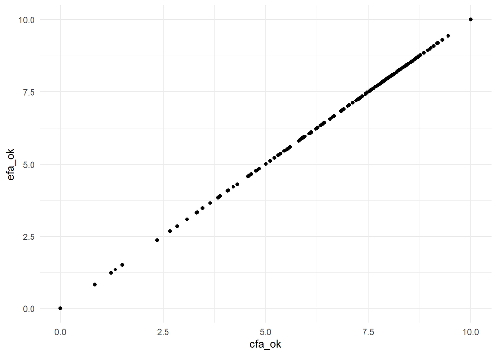

```r
ggplot(data=Alldata,aes(x=cfa_ok,y=efa_ok)) + geom_point() + theme_minimal()
```